# ST 431/531: Sampling Methods

Non Response

Week 9

# Introduction to Nonresponse

## Types of Nonresponse

**Unit nonresponse**: the entire observation for the unit is missing.

**Item nonresponse**: some measurements are present for the observation unit, but at least one is missing.

In agriculture or wildlife surveys, the term *missing data* is often used instead of nonresponse.

## Some Factors Affecting Nonresponse

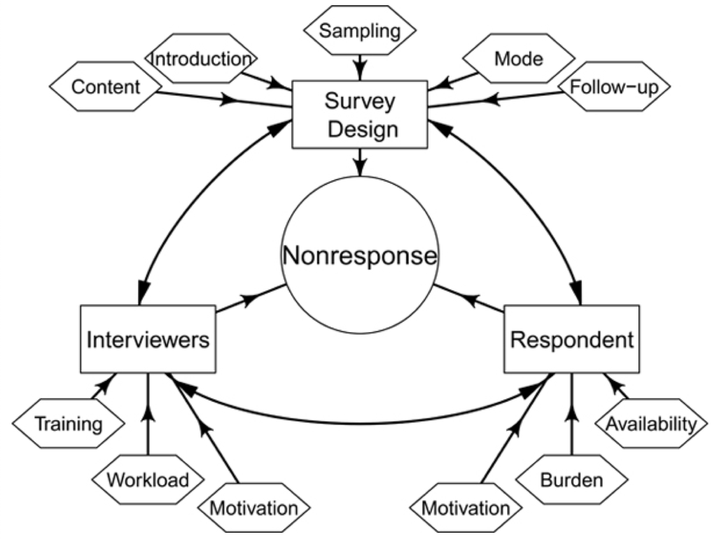

A diagram with nonresponse in the middle being affected by survey design, interviewers, and respondent. Each of those three also affect each other. Survey design is affected by content, introduction, sampling, mode, and follow-up. Interviewers are affected by training, workload, and motivation. Respondent is affected by motivation, burden, and availability.

*Lohr*, Figure 8.1

## Some Reasons for Nonresponse

**Nonresponse** means that the desired data are not obtained for the entire set of sample elements. This can happen for a variety of reasons:

- Impossible to contact: e.g., moved, overseas duty
- Not at home
- Unable to answer: e.g., illness
- Hard core refusal
- Lost questionnaire

Consequence of nonresponse: *missing data*

## Nonresponse Error

If the subpopulation of units who respond is exactly the same as those who don’t respond with respect to the variable(s) of interest, we just end up with a smaller sample than we originally planned on.

But if the non-respondents are different than the respondents with respect to the variable(s) of interest, we may get a **biased** sample.

As the nonresponse rate increases, the amount of bias will often increase.

## Why would someone take time to respond to your survey?

- Reciprocation - what will they gain by participating?
  - Incentives
  - Describing how the survey data will be used
- Authority - surveys that are mandatory, given by a boss, etc.
- Consistency - once someone is persuaded to participate, they may participate in other surveys
- Scarcity - if only “a select few” get to participate, a potential respondent may be more likely to participate
- Social validation - if others participate, you may be more likely to
- Liking the interviewer

## Population Values

Let $N_R$ be the number of would-be respondents and $N_M$ be the number of would-be nonrespondents. Then $N=N_R+N_M$.

Let the population mean of the would-be respondents be $\bar{y}_{R\mathcal{U}}$ and the population mean of the would-be non-respondents be $\bar{y}_{M\mathcal{U}}$.

Then the overall mean of the population is a weighted average of the two group means:
$$\bar{y}_\mathcal{U}=\frac{N_R\bar{y}_{R\mathcal{U}}+N_M\bar{y}_{M\mathcal{U}}}{N}$$

## Nonresponse Error

In the sample, let $\bar{y}_R$ be the mean of the respondents.

Often, it is assumed $E(\bar{y}_R)\approx\bar{y}_{R\mathcal{U}}$ (sample mean of respondents is approximately unbiased).

If $\bar{y}_{R\mathcal{U}}\neq \bar{y}_{M\mathcal{U}}$, then using $\bar{y}_R$ to estimate $\bar{y}_\mathcal{U}$ will be *biased*.

## Nonresponse Error

We can calculate what this bias is:

$$\begin{align*}
\text{bias}(\bar{y}_R) &= E(\bar{y}_R) - \bar{y}_\mathcal{U} \\
&= \frac{N_M}{N}(\bar{y}_{R\mathcal{U}}-\bar{y}_{M\mathcal{U}})
\end{align*}$$

> The bias will be small if either $\frac{N_M}{N}$ is small or $\bar{y}_{R\mathcal{U}}-\bar{y}_{M\mathcal{U}}$ is small.

In these cases, could ignore non-response without terrible consequences.

## Example

Consider a study to obtain the average salary of management staff at Hewlett Packard.

High salary earners may be less inclined to answer the survey than low salary owners. Therefore, high salary earners may be underrepresented in the final data set.

> Would our average salary be accurate? Would it be too high or too low?

## Another Example

*Fish and Wildlife Punch Card Survey*: survey of fishermen to determine the number of fish caught in Oregon Rivers over the past year. (A regulation exists that these cards should be returned to the Fish and Wildlife Service.)

*Respondents*: fisherman returning cards, most cards returned are from those fisherman who caught lots of fish over the past year.

*Nonrespondents*: fisherman who did not return cards.

Result in F&W Survey: “Extrapolation” estimate based on respondents would be an overestimate of the population parameter (total number of fish caught in Oregon).

## A Brief History of Response Rates

U.S. Office of Management and the Budget

Federal Agency Guidelines for Statistical Surveys - Nonresponse

**1979**

Survey Response Rates and Sample Design:

> It is expected that data collections based on statistical methods will have a response rate of at least 75 percent. Proposed data collections having an expected response rate of less than 75% require a special justification. Data collection activities having a response rate $<$ 50% should be terminated.

## A Brief History of Response Rates

**September 2006**

Survey Response Rates:

> Agencies must design the survey to achieve the highest practical rates of response $\ldots$ to ensure that survey results are representative of the target population. Nonresponse bias analyses must be conducted when unit or item response rates or other factors suggest the potential for bias to occur.

## Response rate

**Response rate** calculated for surveys:

$$\text{Response rate}= \frac{\text{Number of eligible units providing data}}{\text{Number of eligible units in sample}}$$

*Example*: telephone survey of 500 current OSU students

## Example Outcomes of Contact

| Description | Eligible | Number of Units in sample |
| --- | --- | --- |
| Completed interviews | Yes | 420 |
| Refused | Yes | 7 |
| No contact with respondent | Yes | 11 |
| Answering machine | Yes | 6 |
| No answer | Yes | 5 |
| Graduated | No | 4 |
| Wrong number | No | 27 |
| Disconnected | No(?) | 19 |
| Unlisted number | No(?) | 1 |
| Total |  | 500 |

## Response Rates

Response rates often presented in surveys:

- Response rate $420/500=84\%$
- Adjusted response rates - several ways of calculating this
  - $420/469 = 90\%$ (dropped two groups in denominator)
  - $420/449 = 93.5\%$ (dropped four groups in denominator)

## Remedies for Nonresponse

Possible remedies fall into three general categories:

1. *Preventative*: Before and during data collection, effective measure are taken to reduce the nonresponse to insignificant levels, so that little impact is made on the inferences.
2. *Special techniques for data collection* are used that permit unbiased estimation. An example is nonrespondent subsampling (two-phase/double sampling).
3. *Adjustment procedures*: Model assumptions about the response mechanisms are made. Information about the relationship between variables is used to construct estimators that “adjust” for nonresponse.

## Preventative Remedies for Nonresponse

- Planning the survey:
  - Choice of data collection method (from highest to lowest response rate: personal interview, mail, telephone, web)
  - Survey burden (repeated survey)
  - Incentives increase response rate (financial, token, when to give)
- Questionnaire design (wording, ordering)
- Callbacks and follow-up increase response rates

## Special Data Collection Techniques

- Subsampling of nonrespondents (nonresponse may still be high)
- (Two-phase/double sampling)
- Randomized response
  - Used in surveys dealing with sensitive questions, such as drug use.
  - Example: Interviewer asks yes/no question. Subject flips coin: if heads, they answer the question; if tails, they respond “yes”. Only the subject (not interviewer) knows the result of the coin flip.
  - People may still refuse to answer or give false information.

## Tips for Designing Surveys to Avoid Nonresponse

Depends on the specific content/context of the survey. General things to consider:

- Know the target population
- Experimental design and quality improvement methods (is a particular mode of survey better?)
- Time of survey: time of the year
- Interviewers: relative comfort with interviewers, skill of interviewers
- Survey introduction: motivation to respond, what data will be used for
- Incentives and disincentives: financial incentives, negative consequences for not participating

# Nonresponse Models

## Response Propensity

We will consider models to explain why a unit doesn’t respond. Let $y_i$ be the response of unit $i$ for the variable of interest. Define the random variable
$$R_i=\begin{cases}1 & \text{if unit }i\text{ responds} \\ 0 & \text{if unit }i\text{ does not respond}\end{cases}$$

After sampling, we observe realizations of $R_i$.

- A value of $y_i$ is recorded if $R_i=1$ for unit $i$.
- Otherwise, $y_i$ is missing.

Then the probability that a unit selected for the sample will respond is

$$\phi_i=P(R_i=1)$$

Rosenbaum and Rubin (1983) call $\phi_i$ the **response propensity** or **propensity score** for the $i$th unit.

## Types of Missing Data

In practice, the $\phi_i$ are unknown and the best we can do is estimate them from the data.

Consider three types of missing data based on the Little and Rubin (originally, 1987)* classification.

1. **Missing Completely at Random** (**MCAR**)
2. **Missing at Random** (**MAR**)
3. **Not Missing at Random** (**NMAR**)

* Little, R.J.A. and D.B. Rubin (2019). *Statistical Analysis with Missing Data, 3rd ed.* Hoboken, NJ: Wiley.

## Missing Completely at Random (MCAR)

> $\phi_i$ does not depend on $\mathbf{x}_i$, $y_i$, or the survey design. There is no difference between the subpopulations of respondents and non-respondents.

A SRS where only some people respond will be like a SRS if everyone responded. The only problem is the reduction in sample size.

Analyze data as collected, no adjustments necessary.

This mechanism is implicity adopted when nonresponse is ignored.

## Missing at Random (MAR)

> $\phi_i$ depends on auxiliary information $\mathbf{x}_i$, but not directly on $y_i$. Sometimes called *missing at random given covariates*. Assume we know $\mathbf{x}_i$ for all sample units or the population totals for the $\mathbf{x}$ variables from the sampling frame or an external source.

Mathematically,
$$P(R_i=1|y_i,\mathbf{x}_i)=P(R_i=1|\mathbf{x}_i)$$

This means that $P(\text{unit }i\text{ responds} | \mathbf{x}_i)$ is independent of $y_i$. Can use $\mathbf{x}_i$ to estimate $\phi_i$, then adjust. This is called *ignorable* nonresponse<sup>1</sup>.

[^1]: because a model can be used such that nonresponse can be ignored after the model accounts for it, not that nonresponse is ignored completely

## MAR Example

Consider a SRS of OSU students to assess satisfaction with the university. The probability of responding is related to things like race, gender, college major (all known). Overall, it may look like satisfaction is related to response propensity. But once students are broken down into groups based on known quantities (e.g., female engineering students), satisfied students are just as likely to respond as unsatisfied students.

- Engineering majors are more likely to return the survey than liberal arts majors
- Engineering majors are more likely to be satisfied than liberal arts majors
- Without a nonresponse correction, we will over-represent engineering majors which will positively bias the overall satisfaction score
- In the MAR setting, if we look just at engineering majors, those who are satisfied are equally as likely to return the survey as those who are not satisfied. Same is true for liberal arts majors, although the response rates can be different.
- View the respondents in each group as a random subsample from the group

## Not Missing at Random (NMAR)

> $\phi_i$ depends on $y_i$ and cannot be completely explained by values that are observed. Non-respondents differ with respect to the variable of interest from the respondents, but not in a way that depends on auxiliary variables we observe.

This is a problem. Can’t adjust for non-response using auxiliary variables, so need to model it with a more complicated approach.

This is *nonignorable* nonresponse.

## Adjustment Procedures for Nonresponse

- Weighting class adjustment
- Poststratification adjustment
- Imputation methods

# Weighting Class Adjustment

## Adjusting Weights to Correct Nonresponse Error

Must assume MAR.

*Recall*: the **sampling weight** of the $i$th population unit is
$$w_i=\frac{1}{\pi_i} \qquad \text{where } \pi_i=P(\text{unit }i\text{ selected in sample})$$

## Review: Sampling Weights

**Quick review**:

| Design | Sampling Weight |
| --- | --- |
| SRS | $w_i=\frac{N}{n}$ |
| Stratified | $w_i=\frac{N_h}{n_h} \qquad \text{for unit }i\text{ in stratum }h$ |
| 2-Stage Cluster | $w_{ij} = \frac{NM_i}{nm_i} \quad \text{for unit }j\text{ in cluster }i$ |

The weight gives the number of population units represented by the sample unit.

## Weighting Class Adjustment

**Weighting class adjustment**: use weights to group sample units into *weighting classes*. Assume that the probability of a response is the same within each class.

$$\begin{align*}
\phi_c &= P(\text{unit }i\text{ in class }c\text{ responds}) \\
&\\
\hat{\phi}_c &= \frac{\text{sum of weights of respondents in class }c}{\text{sum of weights of all sampled units in class }c}
\end{align*}$$

## Weighting Class Adjustment in SRS

In a SRS, all $w_i=\frac{N}{n}$, so

$$\begin{align*}
\hat{\phi}_c &= \frac{\text{# of respondents in class }c}{\text{# of sampled units in class }c} \\
&\\
&= \text{observed response rate in class }c
\end{align*}$$

## Adjusted Weights

The *adjusted weight* for unit $i$ in class $c$ is

$$\tilde{w}_i = \begin{cases}w_i/\hat{\phi}_c & \text{unit }i\text{ responds} \\ 0 & \text{otherwise} \end{cases}$$

The $\tilde{w}_i$ are increased more when $\hat{\phi}_c$ is smaller because respondents have to represent more population units.

## Example

Suppose we have a SRS with observed response rate in class $c$ of $\hat{\phi}_c=\frac{1}{4}$.

Then the adjusted weight for unit $i$ in class $c$ is

$$\tilde{w}_i=\frac{w_i}{\hat{\phi}_c} = \frac{N/n}{1/4}=4\frac{N}{n}$$

This is four times the original weight. Intuitively, each respondent has to represent $\frac{N}{n}$ population units in the original sample plus the three $\frac{N}{n}$ population units not represented by nonrespondents.

## Estimators

Using the weighting class adjustment,

$$\begin{align*}
\hat{t}_{\hat{\phi}} &= \sum_{i\in\mathcal{R}} \tilde{w}_i y_i \\
&\\
\hat{\bar{y}}_{\hat{\phi}} &= \frac{\hat{t}_{\hat{\phi}}}{\sum_{i\in\mathcal{R}} \tilde{w}_i}
\end{align*}$$

Where $\sum_{i\in\mathcal{R}} \tilde{w}_i$ is an estimate for $N$ if it is not known.

Note that $\mathcal{R}$ is the set of respondents, and $\sum_{i\in\mathcal{R}}\tilde{w}_i=\sum_{i\in\mathcal{S}}w_i$ since $\tilde{w}_i=0$ when $i$ does not respond.

## Example

Say we attempt to take a SRS of size 10 from a population of 3000 but get only 7 responses. We know the age for all 10 people we attempted to sample, so we use age to form weighting classes. The data are:

| Weighting Class | $n_c$ | Responses |
| --- | --- | --- |
| Age 18-34 | 4 | 1,2,1 |
| Age 35-50 | 3 | 3,3 |
| Age 51-65 | 3 | 4,2 |

We started with a SRS so $w_i=\frac{N}{n}$ for all $i$.

For unit $i$ in the first weighting class $\tilde{w}_i=\frac{w_i}{\hat{\phi}_i}=\frac{N/n}{n_{rc}/n_c}=\frac{3000/10}{3/4}=400$.

Assign $\tilde{w}_i=0$ if unit $i$ is a nonrespondent.

## Example

Here is a way to visualize what we observe and calculate for all 10 units that we attempted to sample.

The estimate of the population total is

$$\begin{align*}
\hat{t}_{\hat{\phi}}&=\sum_{i\in\mathcal{R}}\tilde{w}_iy_i\\&=7000\end{align*}$$

| Unit | Response $y_i$ | Adj. Weight $\tilde{w}_i$ | $y_i\tilde{w}_i$ |
| --- | --- | --- | --- |
| 1 | 1 | 400 | 400 |
| 2 | 2 | 400 | 800 |
| 3 | 1 | 400 | 400 |
| 4 |  | 0 | 0 |
| 5 | 3 | 450 | 1350 |
| 6 | 3 | 450 | 1350 |
| 7 |  | 0 | 0 |
| 8 | 4 | 450 | 1800 |
| 9 | 2 | 450 | 900 |
| 10 |  | 0 | 0 |
| Sum |  |  | 7000 |

## How to Construct Weighting Classes

Use known variables (e.g. demographic information like age, race, gender, etc.) to construct weighting classes such that

- Response propensities vary from class to class but are relatively homogeneous within a class
- For each key outcome $y$, the values of $y_i$ are similar for nonrespondents and respondents within a weighting class

## Weighting Class Adjustments

Problems can occur if there are more nonrespondents than respondents within a weighting class. In this case, the variance of the estimate increases and the weight may not be stable.

If this occurs, weighting cells can be combined.

In general, weighting adjustment classes should be constructed as if they were strata: want units within classes as similar as possible with respect to the major variables of interest.

# Poststratification

## Poststratification to Adjust for Nonresponse

Recall: Poststratification is a special case of ratio estimation where the auxiliary information is poststratum membership. Here we assume we know $N_h$, the population size of poststratum $h$.

Let

$$x_{hi}=\begin{cases}1 & \text{unit }i\text{ is a respondent in poststratum }h \\ 0 &\text{otherwise}\end{cases}$$

So each population unit has at most one $x_{hi}$ that is non-zero, for poststratum $h=1,\ldots,H$.

## Adjusted Weights

The poststratification adjusted weights are then

$$w_i^*=w_i\sum_{h=1}^H x_{hi}\frac{N_h}{\sum\limits_{j\in\mathcal{R}}w_jx_{hj}}$$

where $\mathcal{R}$ is the set of respondents in the sample.

Think of $\sum\limits_{j\in\mathcal{R}}w_jx_{hj}$ as the sum of weights of respondents in poststratum $h$.

## Poststratification to Adjust for Nonresponse

So for unit $i$ in poststratum $h$,

$$w_i^* = \begin{cases}w_i\left(\frac{N_h}{\text{sum of weights of resp in poststr }h}\right) & \text{unit }i\text{ responds} \\ 0 & \text{unit }i\text{ does not respond} \end{cases}$$

Note that in an SRS, because all the weights are the same,
$$w_i\left(\frac{N_h}{\text{sum of weights of resp in poststr }h}\right)=w_i\left(\frac{N_h}{n_{Rh}w_i} \right)=\frac{N_h}{n_{Rh}}$$
where $n_{Rh}$ is the number of respondents in poststratum $h$.

## Poststratification vs. Weighting Classes

If unit $i$ responds:

$$\begin{align*}
w_i^* &= w_i\left(\frac{N_h}{\text{sum of weights of respondents in poststratum }h}\right) \\
&\\
\tilde{w}_i&=w_i\frac{1}{\hat{\phi}_c} \\
&= w_i \left(\frac{\text{sum of weights of sample units in class }c}{\text{sum of weights of respondents in class }c}\right)
\end{align*}$$

The difference is that in poststratification we use $N_h$ since we know it. In weighting class adjustment, we approximate the number of population units in class $c$ as the sum of the weights.

## Poststratification to Adjust for Nonresponse

The estimators are

$$\begin{align*}
\hat{t}_\text{post} &= \sum_{i\in\mathcal{R}}w_i^*y_i \\
\hat{\bar{y}}_\text{post} &= \frac{\hat{t}_\text{post}}{N}
\end{align*}$$

Poststratification can reduce the variance of estimated population quantities by calibrating the survey to the known population counts.

The estimators are *approximately unbiased* if, within each poststratum $h$,

- Each unit has the same probability of responding OR
- The response propensity $\phi_i$ is the same for every unit OR
- The response $y_i$ is uncorrelated with the response propensity $\phi_i$

## Example

Say we attempt to take a SRS of size 10 from a population of 3000 but get only 7 responses. We know the age for all 10 people we attempted to sample, so we use age to form poststrata. In addition, we know the population counts for the age ranges. The data are:

| Poststratum | $n_h$ | $N_h$ | Responses |
| --- | --- | --- | --- |
| Age 18-34 | 4 | 1500 | 1,2,1 |
| Age 35-50 | 3 | 800 | 3,3 |
| Age 51-65 | 3 | 700 | 4,2 |

We started with a SRS so $w_i=\frac{N}{n}$ for all $i$.

For unit $i$ in the first poststratum $w_i^*=w_i\frac{N_h}{\frac{N}{n}(n_{Rh})}=\frac{3000}{10}\frac{1500}{\frac{3000}{10}(3)}=500$.

Assign $w_i^*=0$ if unit $i$ is a nonrespondent.

## Example

Here is a way to visualize what we observe and calculate for all 10 units that we attempted to sample.

The estimate of the population total is

$$\begin{align*}
\hat{t}_\text{post}&=\sum_{i\in\mathcal{R}}w_i^*y_i\\&=6500\end{align*}$$

| Unit | Response $y_i$ | Adj. Weight $w_i^*$ | $y_iw_i^*$ |
| --- | --- | --- | --- |
| 1 | 1 | 500 | 500 |
| 2 | 2 | 500 | 1000 |
| 3 | 1 | 500 | 500 |
| 4 |  | 0 | 0 |
| 5 | 3 | 400 | 1200 |
| 6 | 3 | 400 | 1200 |
| 7 |  | 0 | 0 |
| 8 | 4 | 350 | 1400 |
| 9 | 2 | 350 | 700 |
| 10 |  | 0 | 0 |
| Sum |  |  | 6500 |

## Raking

**Raking** is a poststratification method that may be used when poststrata are formed using more than one variable, but only the marginal population totals are known.

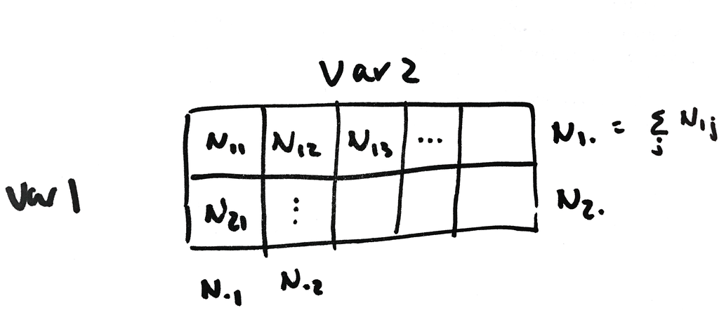

Assume we know $N_{i\cdot}$’s and $N_{\cdot j}$’s, but not $N_{ij}$’s. We could poststratify according to variable 1 or variable 2, but not both together.

## Raking

Raking is an iterative procedure where weights are adjusted across rows to get correct marginals, then across columns, then across rows again, etc. until the marginal totals are correct.

The procedure converges as long as all cell counts are positive.

The procedure has a danger of “overadjustment” - if the extra dimension is not related to the cell means, raking can increase the variance rather than decrease it.

## Comments on Weighting Adjustments

Adjusting weights (by either a weighting class adjustment or poststratification) is not a complete remedy - adjusted data should not be treated as if there was no nonresponse.

Weights may improve many of the estimates, but they rarely eliminate *all* nonresponse bias. The assumed nonresponse model should always be stated and justified when writing up or discussing results.

This type of weighting is usually done for unit nonresponse (whole unit missing), rather than item nonresponse (only some variables missing).

## Imputation

**Imputation** is an alternative method to weighting adjustments to deal with missing data.

The weights are left alone, and values for the missing $y_i$’s are assigned.

Imputation procedures are used to reduce nonresponse bias and to produce a “clean” rectangular data set. We may want to look at many tables for subgroups, and imputation allows us to do that without considering item nonresponse separately each time we construct a table.

## Example

| Person | Age | Sex | Years Education | Crime Victim? | Violent Crime Victim? |
| --- | --- | --- | --- | --- | --- |
| 1 | 47 | M | 16 | 0 | 0 |
| 2 | 45 | F | **?** | 1 | 1 |
| 3 | 19 | M | 11 | 0 | 0 |
| 4 | 21 | F | **?** | 1 | 1 |
| 5 | 24 | M | 12 | 1 | 1 |
| 6 | 41 | F | **?** | 0 | 0 |
| 7 | 36 | M | 20 | 1 | **?** |
| 8 | 50 | M | 12 | 0 | 0 |
| 9 | 53 | F | 13 | 0 | **?** |
| 10 | 17 | M | 10 | **?** | **?** |
| 11 | 53 | F | 12 | 0 | 0 |
| 12 | 21 | F | 12 | 0 | 0 |
| 13 | 18 | F | 11 | 1 | **?** |
| 14 | 34 | M | 16 | 1 | 0 |
| 15 | 44 | M | 14 | 0 | 0 |
| 16 | 45 | M | 11 | 0 | 0 |
| 17 | 54 | F | 14 | 0 | 0 |
| 18 | 55 | F | 10 | 0 | 0 |
| 19 | 29 | F | 12 | **?** | 0 |
| 20 | 32 | F | 10 | 0 | 0 |

## Cell Mean Imputation

Respondents are divided into classes (cells) based on known variables, as in weighting class adjustments.

The average of the values for the responding units in cell $c$, $\bar{y}_{Rc}$, is substituted for each missing value.

This assumes that missing items are completely random within cells.

This probably ignores some variability.

## Cell Mean Imputation - Example

The age and sex of every person are known, so we form the following cells:

|  | Age $\leq 34$ | Age $\geq 35$ |
| --- | --- | --- |
| **Sex M** | Persons 3, 5, 10, 14 | Persons 1, 7, 8, 15, 16 |
| **Sex F** | Persons 4, 12, 13, 19, 20 | Persons 2, 6, 9, 11, 17, 18 |

Persons 2, 4, and 6 are missing the “years education” variable.

- Persons 2 and 6 are both in the same cell, so they would be assigned the mean years of education of the four respondents in that cell (13+12+14+10)/4=12.25
- Person 4 would be assigned the mean years of education for the four respondents in their cell (12+11+12+10)/4=11.25

## Cell Mean Imputation Example

| Person | Age | Sex | Years Education | Crime Victim? | Violent Crime Victim? |
| --- | --- | --- | --- | --- | --- |
| 1 | 47 | M | 16 | 0 | 0 |
| 2 | 45 | F | **? –> 12.25** | 1 | 1 |
| 3 | 19 | M | 11 | 0 | 0 |
| 4 | 21 | F | **? –> 11.25** | 1 | 1 |
| 5 | 24 | M | 12 | 1 | 1 |
| 6 | 41 | F | **? –> 12.25** | 0 | 0 |
| 7 | 36 | M | 20 | 1 | **?** |
| 8 | 50 | M | 12 | 0 | 0 |
| 9 | 53 | F | 13 | 0 | **?** |
| 10 | 17 | M | 10 | **?** | **?** |
| 11 | 53 | F | 12 | 0 | 0 |
| 12 | 21 | F | 12 | 0 | 0 |
| 13 | 18 | F | 11 | 1 | **?** |
| 14 | 34 | M | 16 | 1 | 0 |
| 15 | 44 | M | 14 | 0 | 0 |
| 16 | 45 | M | 11 | 0 | 0 |
| 17 | 54 | F | 14 | 0 | 0 |
| 18 | 55 | F | 10 | 0 | 0 |
| 19 | 29 | F | 12 | **?** | 0 |
| 20 | 32 | F | 10 | 0 | 0 |

## Cell Mean Imputation

Cell mean imputation gives the same point estimates for means, totals, and proportions as the weighting class adjustments.

However, mean imputation methods fail to reflect the variability of the respondents, so the distribution of $y$ will have a “spike” at the value of the sample mean. The estimated variance of the subclass will be too small.

## Hot-Deck Imputation

The sample units are divided into classes as with weighting class adjustments and cell mean imputation.

The value of **one** of the responding units in the class (the **donor**) is substituted for each missing response.

(The name *hot-deck* is from time when computer programs were punched on cards, and the deck of cards containing the data set being analyzed was warmed by the card reader.)

## Sequential Hot-Deck Imputation

How is the “donor” chosen?

In **Sequential Hot-Deck Imputation**, units are ordered in some way, and then the respondent prior to a nonrespondent is used to impute the nonrespondent’s value.

Problem: nonrespondents are often clustered, so one respondent’s value may be used as the imputed value for several nonrespondents.

## Sequential Hot-Deck Imputation Example

The highlighted rows are for the F, $\leq$ 34 class.

| Person | Age | Sex | Years Education | Crime Victim? | Violent Crime Victim? |
| --- | --- | --- | --- | --- | --- |
| 1 | 47 | M | 16 | 0 | 0 |
| 2 | 45 | F | **12.25** | 1 | 1 |
| 3 | 19 | M | 11 | 0 | 0 |
| 4 | 21 | F | **11.25** | 1 | 1 |
| 5 | 24 | M | 12 | 1 | 1 |
| 6 | 41 | F | **12.25** | 0 | 0 |
| 7 | 36 | M | 20 | 1 | **?** |
| 8 | 50 | M | 12 | 0 | 0 |
| 9 | 53 | F | 13 | 0 | **?** |
| 10 | 17 | M | 10 | **?** | **?** |
| 11 | 53 | F | 12 | 0 | 0 |
| 12 | 21 | F | 12 | 0 | 0 |
| 13 | 18 | F | 11 | 1 (**donor**) | **?** |
| 14 | 34 | M | 16 | 1 | 0 |
| 15 | 44 | M | 14 | 0 | 0 |
| 16 | 45 | M | 11 | 0 | 0 |
| 17 | 54 | F | 14 | 0 | 0 |
| 18 | 55 | F | 10 | 0 | 0 |
| 19 | 29 | F | 12 | **? –> 1** | 0 |
| 20 | 32 | F | 10 | 0 | 0 |

## Random Hot-Deck Imputation

How is the “donor” chosen?

In **Random Hot-Deck Imputation**, a donor is randomly chosen from the persons in the cell with information on all missing items. To preserve multivariate relationships, usually values from the same donor are used for all missing items of a person.

## Random Hot-Deck Imputation Example

The highlighted rows are for the M, $\leq$ 34 class.

| Person | Age | Sex | Years Education | Crime Victim? | Violent Crime Victim? |
| --- | --- | --- | --- | --- | --- |
| 1 | 47 | M | 16 | 0 | 0 |
| 2 | 45 | F | **12.25** | 1 | 1 |
| 3 | 19 | M | 11 | 0 | 0 |
| 4 | 21 | F | **11.25** | 1 | 1 |
| 5 | 24 | M | 12 | 1 | 1 |
| 6 | 41 | F | **12.25** | 0 | 0 |
| 7 | 36 | M | 20 | 1 | **?** |
| 8 | 50 | M | 12 | 0 | 0 |
| 9 | 53 | F | 13 | 0 | **?** |
| 10 | 17 | M | 10 | **? –> 1** | **? –> 0** |
| 11 | 53 | F | 12 | 0 | 0 |
| 12 | 21 | F | 12 | 0 | 0 |
| 13 | 18 | F | 11 | 1 | **?** |
| 14 | 34 | M | 16 | 1 (**donor**) | 0 (**donor**) |
| 15 | 44 | M | 14 | 0 | 0 |
| 16 | 45 | M | 11 | 0 | 0 |
| 17 | 54 | F | 14 | 0 | 0 |
| 18 | 55 | F | 10 | 0 | 0 |
| 19 | 29 | F | 12 | **1** | 0 |
| 20 | 32 | F | 10 | 0 | 0 |

## Nearest-Neighbor Hot-Deck Imputation

How is the “donor” chosen?

In **Nearest-Neighbor Hot-Deck Imputation**, a distance measure is defined between observations. The imputed value for the nonrespondent is from the respondent who is “closest” to the nonrespondent using this distance measure.

Example: Select the person of the same sex who is closest in age.

## Nearest Neighbor Hot-Deck Imputation Example

The highlighted rows are for the M, $\leq$ 34 class.

| Person | Age | Sex | Years Education | Crime Victim? | Violent Crime Victim? |
| --- | --- | --- | --- | --- | --- |
| 1 | 47 | M | 16 | 0 | 0 |
| 2 | 45 | F | **12.25** | 1 | 1 |
| 3 | 19 | M | 11 | 0 (**donor**) | 0 (**donor**) |
| 4 | 21 | F | **11.25** | 1 | 1 |
| 5 | 24 | M | 12 | 1 | 1 |
| 6 | 41 | F | **12.25** | 0 | 0 |
| 7 | 36 | M | 20 | 1 | **?** |
| 8 | 50 | M | 12 | 0 | 0 |
| 9 | 53 | F | 13 | 0 | **?** |
| 10 | 17 | M | 10 | **? –> 0** | **? –> 0** |
| 11 | 53 | F | 12 | 0 | 0 |
| 12 | 21 | F | 12 | 0 | 0 |
| 13 | 18 | F | 11 | 1 | **?** |
| 14 | 34 | M | 16 | 1 | 0 |
| 15 | 44 | M | 14 | 0 | 0 |
| 16 | 45 | M | 11 | 0 | 0 |
| 17 | 54 | F | 14 | 0 | 0 |
| 18 | 55 | F | 10 | 0 | 0 |
| 19 | 29 | F | 12 | **1** | 0 |
| 20 | 32 | F | 10 | 0 | 0 |

## Hot-Deck Imputation

Generally, we need large samples to do hot-deck imputation.

For small samples, it is less likely that a suitable donor will be found for nonrespondents.

Hot-deck imputation is not guaranteed to eliminate nonresponse bias.

## Cold-Deck Imputation

In **cold-deck imputation**, the imputed values come from a previous study or other information (such as historical data).

Useful for repeated surveys.

Not guaranteed to eliminate nonresponse bias.

## Regression Imputation

Regression imputation predicts the missing value using a regression of the item of interest on variables observed for all cases.

The type of regression model used depends on the type of missing variable.

- Use linear regression for continuous variables with missing values
- Use logistic regression for binary variables with missing values
- Etc.

## Regression Imputation - Example

We have 18 complete observations for the “Crime Victim?” variable, which is binary.

Fit a logistic regression model using age as the explanatory variable.

```r
crimevic <- c(0,1,0,1,1,0,1,0,0,NA,0,0,1,1,0,0,0,0,NA,0)
age <- c(47,45,19,21,24,41,36,50,53,17,
         53,21,18,34,44,45,54,55,29,32)
glm(crimevic ~ age, family=binomial)
```

```
Call:  glm(formula = crimevic ~ age, family = binomial)

Coefficients:
(Intercept)          age
    2.56427     -0.08958

Degrees of Freedom: 17 Total (i.e. Null);  16 Residual
  (2 observations deleted due to missingness)
Null Deviance:      22.91
Residual Deviance: 18.5     AIC: 22.5
```

## Regression Imputation - Example

The logistic regression model is
$$\log \frac{\hat{p}}{1-\hat{p}}=2.56427-0.08958\times\text{age}$$

- Thus, for person 10 (who is 17 years old), we calculate
  $$\log \frac{\hat{p}}{1-\hat{p}}=2.56427-0.08958(17)=1.04141$$
  and thus $\hat{p}=\frac{e^{1.04141}}{(1+e^{1.04141})}=0.74$. This is larger than the cutoff of 0.5, so a value of 1 is imputed.
- For person 19, the imputed value is a 0.

## Regression Imputation Example

| Person | Age | Sex | Years Education | Crime Victim? | Violent Crime Victim? |
| --- | --- | --- | --- | --- | --- |
| 1 | 47 | M | 16 | 0 | 0 |
| 2 | 45 | F | **12.25** | 1 | 1 |
| 3 | 19 | M | 11 | 0 | 0 |
| 4 | 21 | F | **11.25** | 1 | 1 |
| 5 | 24 | M | 12 | 1 | 1 |
| 6 | 41 | F | **12.25** | 0 | 0 |
| 7 | 36 | M | 20 | 1 | **?** |
| 8 | 50 | M | 12 | 0 | 0 |
| 9 | 53 | F | 13 | 0 | **?** |
| 10 | 17 | M | 10 | **? –> 1** | **?** |
| 11 | 53 | F | 12 | 0 | 0 |
| 12 | 21 | F | 12 | 0 | 0 |
| 13 | 18 | F | 11 | 1 | **?** |
| 14 | 34 | M | 16 | 1 | 0 |
| 15 | 44 | M | 14 | 0 | 0 |
| 16 | 45 | M | 11 | 0 | 0 |
| 17 | 54 | F | 14 | 0 | 0 |
| 18 | 55 | F | 10 | 0 | 0 |
| 19 | 29 | F | 12 | **? –> 0** | 0 |
| 20 | 32 | F | 10 | 0 | 0 |

## Stochastic Versions of Imputation

In the approaches we’ve looked at so far, we would impute the same value each time we ran through the imputation procedure.

In a **stochastic** approach, use a method, then add some random noise.

*Example*: instead of the cell mean, use a draw from a normal distribution centered at the cell mean with some specified standard deviation.

## Multiple Imputation

Each missing value is imputed $m\geq 2$ different times. Typically, the same stochastic model is used for each imputation.

This creates $m$ different data sets with no missing values. Each data set is analyzed as if no imputation had been done. This may create, for example, $m$ different estimates of a population parameter. How different these estimates are is a measure of additional variance due to imputation.

If different models for nonresponse are used, multiple imputation can give an idea of the sensitivity of the result on the particular nonresponse model used.

## Multiple Imputation

We create $m$ different data sets using an imputation method. We then have $m$ estimates of $t$:
$$\hat{t}^{(1)}, \ldots, \hat{t}^{(m)}$$

The ultimate estimate of $t$ will then be the average of these estimates
$$\hat{t}_\text{MI}=\frac{1}{m}\sum_{k=1}^m \hat{t}^{(k)}$$

## Imputation Conclusion

If the nonresponse is missing at random (MAR) given the covariates used in the imputation procedure, imputation substantially reduces the bias due to item nonresponse.

Pro: Imputation can be done using restricted variables which are not released to the public. Nonresponse is then accounted for and the variable of interest is “complete”.

Con: Future analysts cannot distinguish between the original and imputed values. If the imputed values are treated as if they were observed in the survey, the estimated variance will be too small.